# Билет 8

```python
import numpy as np
import matplotlib.pyplot as plt
import matplotlib
```

### Задача 1

#### Понятие непрерывности функции в точке и на множестве. Арифметические операции над непрерывными функциями. Классификация точек разрыва.

Функция является непрерывной в точке $ a $, если $ \lim\limits_{x \to a} f(x) = f(a) $  
Функция является непрерывной на множестве $ A $, если $ \forall a \in A \ \lim\limits_{x \to a} f(x) = f(a) $  
Пусть $ f, g $ - непрерывны в точке $ a $ . Тогда $ f \pm g, f \cdot g, \frac{f}{g} \ (g(a) != 0) $ являются непрерывными в точке $ a $

Устранимый разрыв в точке $ a $: $ \exists \lim\limits_{x \to a} f(x) \not = f(a) $  
Разрыв 1-го рода в точке $ a $: $ \exists \lim\limits_{x \to x - a} f(x), \lim\limits_{x \to x + a} f(x), \lim\limits_{x \to x - a} f(x) \not = \lim\limits_{x \to x + a} f(x) $  
Разрыв 2-го рода в точке $ a $: хотя бы один из пределов $ a - 0, a + 0 $ не существует или равен $ \infty $

### Задача 2

#### Определение, свойства и график функции $ y=arcctg \ x $

$ X = \mathbb{R}, Y = [-\frac{\pi}{2}, \frac{\pi}{2}] $

Функция непериодическая

Функция прерывается в точке $ 0 $

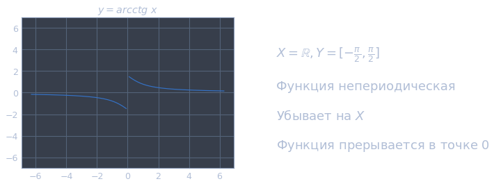

```python
x = np.linspace(- 2 * np.pi, 2 * np.pi, 200)
x[np.abs(x) < 0.05] = np.nan
y = np.arctan(1 / x)

matplotlib.rcParams.update({'font.size': 18})

fig, axs = plt.subplots(1, 2, figsize=(12, 4))
axs[0].set_ylim([-7, 7])
axs[0].plot(x, y)
axs[0].set_title('$ y=arcctg \ x $')

axs[1].axis('off')
axs[1].text(0, 0.02, r"""
$ X = \mathbb{R}, Y = [-\frac{\pi}{2}, \frac{\pi}{2}] $

Функция непериодическая

Убывает на $ X $

Функция прерывается в точке $ 0 $
""")
plt.show()
```

### Задача 3

#### Определение бесконечно малой (не бесконечно малой) числовой последовательности.

Последовательность называется бесконечно малой, если $ \forall \varepsilon \ \exists N(\varepsilon): \forall n \geqslant N \ |x_n| < \varepsilon $

Последовательность называется не бесконечно малой, если $ \exists \varepsilon \ \forall N(\varepsilon): \forall n \geqslant N \ |x_n| \geqslant \varepsilon $

### Задача 4

Дать определение по Коши: неверно, что $ \lim\limits_{x \to a} f(x) = \infty $

$ \lim\limits_{x \to a} f(x) \not = \infty \Leftrightarrow \exists \varepsilon > 0 \ \forall \delta(\varepsilon) > 0: \exists x \in (a - \delta, a + \delta), |f(x)| < \varepsilon $

### Задача 5

#### Определение функции, непрерывной в точке $ a $ справа.

Пусть $ a \in X $. Функция $ f $ непрерывна в точке $ a $ справа, если $ \lim\limits_{x \to a + 0} f(x) = f(a) $